# Risk Factor Analysis

## Outcome Variable

**Outcome Variable:** whz

## Predictor Variables

**Intervention Variable:** brthmon

**Adjustment Set:**

unadjusted

## Stratifying Variables

The analysis was stratified on these variable(s):

- agecat

## Data Summary

| agecat | brthmon | n_cell | n |
| --- | --- | --- | --- |
| Birth | 1 | 3861 | 46768 |
| Birth | 2 | 3459 | 46768 |
| Birth | 3 | 4043 | 46768 |
| Birth | 4 | 3406 | 46768 |
| Birth | 5 | 3005 | 46768 |
| Birth | 6 | 3197 | 46768 |
| Birth | 7 | 3602 | 46768 |
| Birth | 8 | 4031 | 46768 |
| Birth | 9 | 4439 | 46768 |
| Birth | 10 | 4516 | 46768 |
| Birth | 11 | 4481 | 46768 |
| Birth | 12 | 4728 | 46768 |
| 6 months | 1 | 4254 | 58840 |
| 6 months | 2 | 4224 | 58840 |
| 6 months | 3 | 5170 | 58840 |
| 6 months | 4 | 4494 | 58840 |
| 6 months | 5 | 4310 | 58840 |
| 6 months | 6 | 4335 | 58840 |
| 6 months | 7 | 5031 | 58840 |
| 6 months | 8 | 5612 | 58840 |
| 6 months | 9 | 5441 | 58840 |
| 6 months | 10 | 5374 | 58840 |
| 6 months | 11 | 5293 | 58840 |
| 6 months | 12 | 5302 | 58840 |
| 24 months | 1 | 1525 | 24610 |
| 24 months | 2 | 2140 | 24610 |
| 24 months | 3 | 2481 | 24610 |
| 24 months | 4 | 2003 | 24610 |
| 24 months | 5 | 1737 | 24610 |
| 24 months | 6 | 1835 | 24610 |
| 24 months | 7 | 2245 | 24610 |
| 24 months | 8 | 2232 | 24610 |
| 24 months | 9 | 2120 | 24610 |
| 24 months | 10 | 2039 | 24610 |
| 24 months | 11 | 2013 | 24610 |
| 24 months | 12 | 2240 | 24610 |

The following strata were considered:

- agecat: 24 months
- agecat: 6 months
- agecat: Birth

## Methods Detail

We’re interested in the causal parameters $E[Y_a]$ for all values of $a \in \mathcal{A}$. These parameters represent the mean outcome if, possibly contrary to fact, we intervened to set all units to have $A=a$. Under the randomization and positivity assumptions, these are identified by the statistical parameters $\psi_a=E_W[E_{Y|A,W}(Y|A=a,W)]$. In addition, we’re interested in the mean of $Y$, $E[Y]$ under no intervention (the observed mean). We will estimate these parameters by using SuperLearner to fit the relevant likelihood factors – $E_{Y|A,W}(Y|A=a,W)$ and $p(A=a|W)$, and then updating our likelihood fit using a joint TMLE.

For unadjusted analyses ($W=\{\}$), initial likelihoods were estimated using Lrnr_glm to estimate the simple $E(Y|A)$ and Lrnr_mean to estimate $p(A)$. For adjusted analyses, a small library containing Lrnr_glmnet, Lrnr_xgboost, and Lrnr_mean was used.

Having estimated these parameters, we will then use the delta method to estimate relative risks and attributable risks relative to a prespecified baseline level of $A$.

# Results Detail

## Results Plots

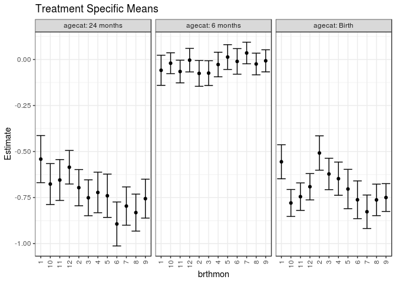

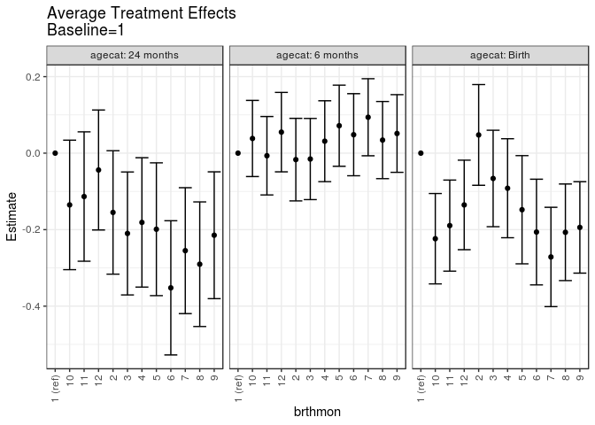

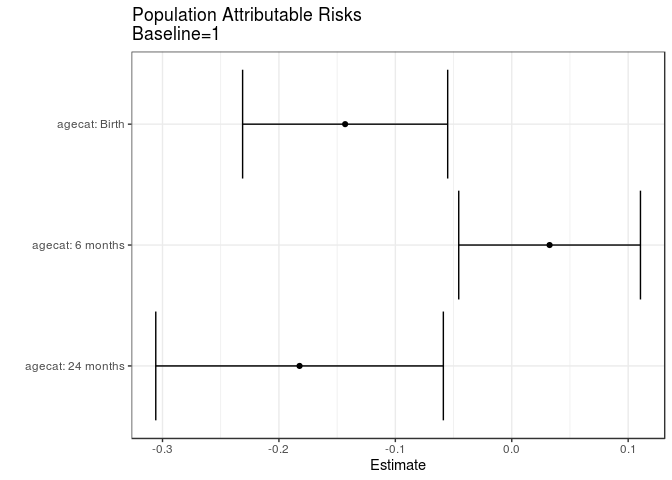

## Results Table

### Parameter: TSM

| agecat | intervention_level | baseline_level | estimate | ci_lower | ci_upper |
| --- | --- | --- | --- | --- | --- |
| Birth | 1 | NA | -0.5555400 | -0.6480218 | -0.4630582 |
| Birth | 2 | NA | -0.5079329 | -0.6011764 | -0.4146895 |
| Birth | 3 | NA | -0.6217660 | -0.7070649 | -0.5364671 |
| Birth | 4 | NA | -0.6473282 | -0.7374602 | -0.5571963 |
| Birth | 5 | NA | -0.7034676 | -0.8102542 | -0.5966809 |
| Birth | 6 | NA | -0.7618580 | -0.8643242 | -0.6593917 |
| Birth | 7 | NA | -0.8269711 | -0.9179036 | -0.7360386 |
| Birth | 8 | NA | -0.7624932 | -0.8480910 | -0.6768953 |
| Birth | 9 | NA | -0.7497116 | -0.8252455 | -0.6741777 |
| Birth | 10 | NA | -0.7792958 | -0.8523877 | -0.7062040 |
| Birth | 11 | NA | -0.7449676 | -0.8196264 | -0.6703089 |
| Birth | 12 | NA | -0.6909497 | -0.7624527 | -0.6194466 |
| 6 months | 1 | NA | -0.0585864 | -0.1403965 | 0.0232236 |
| 6 months | 2 | NA | -0.0755230 | -0.1456611 | -0.0053850 |
| 6 months | 3 | NA | -0.0739214 | -0.1411970 | -0.0066458 |
| 6 months | 4 | NA | -0.0273471 | -0.0941005 | 0.0394063 |
| 6 months | 5 | NA | 0.0131576 | -0.0542261 | 0.0805413 |
| 6 months | 6 | NA | -0.0104143 | -0.0798870 | 0.0590584 |
| 6 months | 7 | NA | 0.0352726 | -0.0233261 | 0.0938712 |
| 6 months | 8 | NA | -0.0244375 | -0.0832992 | 0.0344241 |
| 6 months | 9 | NA | -0.0071895 | -0.0671525 | 0.0527734 |
| 6 months | 10 | NA | -0.0202565 | -0.0768666 | 0.0363535 |
| 6 months | 11 | NA | -0.0653603 | -0.1269245 | -0.0037962 |
| 6 months | 12 | NA | -0.0036424 | -0.0674053 | 0.0601205 |
| 24 months | 1 | NA | -0.5411022 | -0.6690833 | -0.4131210 |
| 24 months | 2 | NA | -0.6961093 | -0.7944657 | -0.5977528 |
| 24 months | 3 | NA | -0.7510634 | -0.8485899 | -0.6535369 |
| 24 months | 4 | NA | -0.7221934 | -0.8323885 | -0.6119983 |
| 24 months | 5 | NA | -0.7400576 | -0.8576350 | -0.6224801 |
| 24 months | 6 | NA | -0.8932825 | -1.0127701 | -0.7737949 |
| 24 months | 7 | NA | -0.7960710 | -0.8999987 | -0.6921433 |
| 24 months | 8 | NA | -0.8315122 | -0.9319583 | -0.7310662 |
| 24 months | 9 | NA | -0.7557234 | -0.8613722 | -0.6500746 |
| 24 months | 10 | NA | -0.6764274 | -0.7875858 | -0.5652689 |
| 24 months | 11 | NA | -0.6545877 | -0.7655458 | -0.5436296 |
| 24 months | 12 | NA | -0.5851272 | -0.6763532 | -0.4939011 |

### Parameter: E(Y)

| agecat | intervention_level | baseline_level | estimate | ci_lower | ci_upper |
| --- | --- | --- | --- | --- | --- |
| Birth | NA | NA | -0.6986551 | -0.7229461 | -0.6743640 |
| 6 months | NA | NA | -0.0260821 | -0.0445951 | -0.0075691 |
| 24 months | NA | NA | -0.7233768 | -0.7539725 | -0.6927811 |

### Parameter: ATE

| agecat | intervention_level | baseline_level | estimate | ci_lower | ci_upper |
| --- | --- | --- | --- | --- | --- |
| Birth | 1 | 1 | 0.0000000 | 0.0000000 | 0.0000000 |
| Birth | 2 | 1 | 0.0476071 | -0.0840687 | 0.1792829 |
| Birth | 3 | 1 | -0.0662260 | -0.1923148 | 0.0598628 |
| Birth | 4 | 1 | -0.0917882 | -0.2211939 | 0.0376174 |
| Birth | 5 | 1 | -0.1479275 | -0.2893343 | -0.0065208 |
| Birth | 6 | 1 | -0.2063180 | -0.3444927 | -0.0681433 |
| Birth | 7 | 1 | -0.2714311 | -0.4012477 | -0.1416145 |
| Birth | 8 | 1 | -0.2069532 | -0.3332583 | -0.0806480 |
| Birth | 9 | 1 | -0.1941716 | -0.3137018 | -0.0746415 |
| Birth | 10 | 1 | -0.2237558 | -0.3418930 | -0.1056186 |
| Birth | 11 | 1 | -0.1894276 | -0.3084918 | -0.0703634 |
| Birth | 12 | 1 | -0.1354096 | -0.2524420 | -0.0183772 |
| 6 months | 1 | 1 | 0.0000000 | 0.0000000 | 0.0000000 |
| 6 months | 2 | 1 | -0.0169366 | -0.1248575 | 0.0909844 |
| 6 months | 3 | 1 | -0.0153350 | -0.1214546 | 0.0907846 |
| 6 months | 4 | 1 | 0.0312393 | -0.0745094 | 0.1369881 |
| 6 months | 5 | 1 | 0.0717440 | -0.0343232 | 0.1778113 |
| 6 months | 6 | 1 | 0.0481721 | -0.0591497 | 0.1554939 |
| 6 months | 7 | 1 | 0.0938590 | -0.0068688 | 0.1945868 |
| 6 months | 8 | 1 | 0.0341489 | -0.0666911 | 0.1349889 |
| 6 months | 9 | 1 | 0.0513969 | -0.0501408 | 0.1529346 |
| 6 months | 10 | 1 | 0.0383299 | -0.0612182 | 0.1378779 |
| 6 months | 11 | 1 | -0.0067739 | -0.1092833 | 0.0957355 |
| 6 months | 12 | 1 | 0.0549441 | -0.0488604 | 0.1587485 |
| 24 months | 1 | 1 | 0.0000000 | 0.0000000 | 0.0000000 |
| 24 months | 2 | 1 | -0.1550071 | -0.3163849 | 0.0063708 |
| 24 months | 3 | 1 | -0.2099612 | -0.3707308 | -0.0491916 |
| 24 months | 4 | 1 | -0.1810912 | -0.3501941 | -0.0119883 |
| 24 months | 5 | 1 | -0.1989554 | -0.3726262 | -0.0252845 |
| 24 months | 6 | 1 | -0.3521803 | -0.5276026 | -0.1767580 |
| 24 months | 7 | 1 | -0.2549688 | -0.4195436 | -0.0903940 |
| 24 months | 8 | 1 | -0.2904101 | -0.4532773 | -0.1275428 |
| 24 months | 9 | 1 | -0.2146212 | -0.3803985 | -0.0488440 |
| 24 months | 10 | 1 | -0.1353252 | -0.3046346 | 0.0339842 |
| 24 months | 11 | 1 | -0.1134855 | -0.2826464 | 0.0556754 |
| 24 months | 12 | 1 | -0.0440250 | -0.2009003 | 0.1128504 |

### Parameter: PAR

| agecat | intervention_level | baseline_level | estimate | ci_lower | ci_upper |
| --- | --- | --- | --- | --- | --- |
| Birth | 1 | NA | -0.1431150 | -0.2311935 | -0.0550366 |
| 6 months | 1 | NA | 0.0325043 | -0.0455447 | 0.1105533 |
| 24 months | 1 | NA | -0.1822746 | -0.3057864 | -0.0587628 |